# Bycatch Data Submission

Lobster Group, Science Branch

**1. Data was collected**

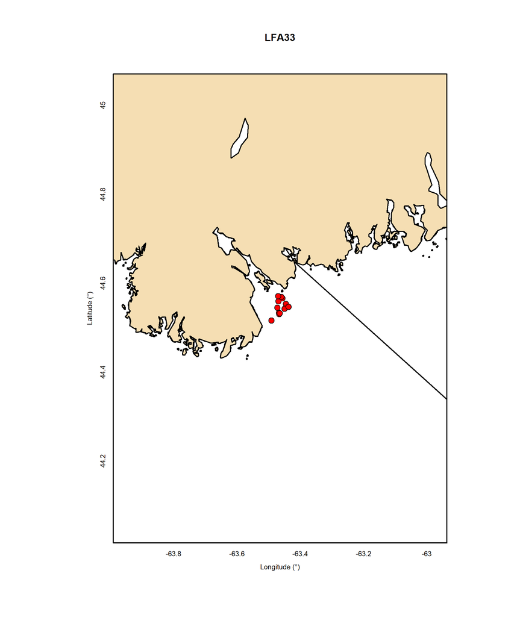

**2. What group entered the data and the name of the data file that was imported**

SWLSS 108749-210423

All locations match LFA

All locations match grids

**4. Are males berried or notched?**

No Males are V-notched

**5. Is the length between a reasonable size 30-250mm?**

Carapace sizes reasonable

**6. Is Length, Shell, Disease, Sex and Condition recorded for all Lobster?**

Carapace lengths recorded

Shell hardness recorded

Disease status recorded

Sex recorded

Condition recorded

**7. Is the depth less than a maximum fishing depth ?**

Depths within reasonable range

**8. Were any lobster kept below the MLS for the given LFA?**

No small lobsters retained

**9. Were female between 114-124mm kept in LFA 31a?**

No window restricted lobsters were kept

**10. Were v-notched lobster retained in prohibited LFAs?**

No vnotched lobster retained in prohibited area

**11. Is abundance greater than 1 for anything other than whelks, starfish, urchins?**

Abundance is correct

**12. If species is not a berried lobster does it have clutch and egg categories filled out?**

Only berried females have egg and clutch information

**13. If a lobster is berried is egg stage and clutch size recorded?**

Berried females have egg and clutch information

**14. Do all crab species entries have length, sex and condition recorded?**

All crabs have length and sex recorded

Condition recorded

**15. Does anything other than a lobster have the notch category filled out?**

Only lobster have notches

**16. Do all Fish species entries have length, condition recorded?**

All fish have length recorded

All fish have condition recorded

**18. What is the total number of traps sampled and total traps hauled**

Total number of traps sampled: 121

Total number of traps hauled: 250

**19. What was the total number of lobsters and other species sampled?**

Total number of lobsters sampled: 200

Total number of non lobsters sampled: 28

Total number of species: 8

Total number of individuals sampled: 228

Total number of traps sampled: 121